# SR_03_RLTD_ORG_PTR_ADDR_L2

Related organization street address line 2 · Text report

## Overview

**Description**

Address Foreign - AddressLine2

**Table**

`SR-P03-T01-ID-RLTD-ORGS-TAXABLE-PARTNERSHIP` (many)

**Location code**

`SCHED-R-PART-03-COL-A`

**Family**

`SCHED-R-PART-03-COL-A` · siblings: SR_03_RLTD_ORG_PTR_ADDR_CITY, SR_03_RLTD_ORG_PTR_ADDR_CNTR, SR_03_RLTD_ORG_PTR_ADDR_L1, SR_03_RLTD_ORG_PTR_ADDR_STATE, SR_03_RLTD_ORG_PTR_ADDR_ZIP, SR_03_RLTD_ORG_PTR_EIN

**Data type**

text (xsd: StreetAddressType)

**Scope**

PC

**Status**

unreviewed

6

xpaths mapped (6 observed)

4,460

filings with a value

2009–2024

tax years observed

5

open flags (1 errors)

## Flags

| Severity | Flag | Xpath | Detail |
| --- | --- | --- | --- |
| ⚠ error | `COLLISION` | IRS990ScheduleR/IdRelatedOrgTxblPartnershipGrp/ForeignAddress/AddressLine2Txt | 108 filings contain 2+ of its xpaths; most common set: /Return/ReturnData/IRS990ScheduleR/IdRelatedOrgTxblPartnershipGrp/ForeignAddress/AddressLine2Txt ; /Return/ReturnData/IRS990ScheduleR/IdRelatedOr… |
| ⓘ info | `MANY_NOT_REPEATING` | IRS990ScheduleR/Form990ScheduleRPartIII/AddressUS/AddressLine2 | many-to-one table, but 52% of values sit in no repeating element |
| ⓘ info | `MANY_NOT_REPEATING` | IRS990ScheduleR/IdRelatedOrgTxblPartnershipGrp/USAddress/AddressLine2 | many-to-one table, but 53% of values sit in no repeating element |
| ⓘ info | `MANY_NOT_REPEATING` | IRS990ScheduleR/Form990ScheduleRPartIII/AddressForeign/AddressLine2 | many-to-one table, but 100% of values sit in no repeating element |
| ⓘ info | `MANY_NOT_REPEATING` | IRS990ScheduleR/IdRelatedOrgTxblPartnershipGrp/ForeignAddress/AddressLine2 | many-to-one table, but 100% of values sit in no repeating element |

## Xpaths

All mapped xpaths (under /Return/ReturnData or /Return/ReturnHeader), oldest first. Charts label each series by its xpath.

| Xpath | Form | Chart label | First year | Last year | Versions | Filings | Repeats in |
| --- | --- | --- | --- | --- | --- | --- | --- |
| IRS990ScheduleR/Form990ScheduleRPartIII/AddressUS/AddressLine2 | Sched R | …0ScheduleR/Form990ScheduleRPartIII/AddressUS/AddressLine2 | 2009 | 2012 | 10 | 124 | 41.9% |
| IRS990ScheduleR/Form990ScheduleRPartIII/AddressForeign/AddressLine2 | Sched R | …duleR/Form990ScheduleRPartIII/AddressForeign/AddressLine2 | 2012 | 2012 | 1 | 2 | 0.0% |
| IRS990ScheduleR/IdRelatedOrgTxblPartnershipGrp/USAddress/AddressLine2 | Sched R | …leR/IdRelatedOrgTxblPartnershipGrp/USAddress/AddressLine2 | 2013 | 2013 | 3 | 53 | 41.5% |
| IRS990ScheduleR/IdRelatedOrgTxblPartnershipGrp/ForeignAddress/AddressLine2 | Sched R | …dRelatedOrgTxblPartnershipGrp/ForeignAddress/AddressLine2 | 2013 | 2013 | 2 | 2 | 0.0% |
| IRS990ScheduleR/IdRelatedOrgTxblPartnershipGrp/USAddress/AddressLine2Txt | Sched R | …/IdRelatedOrgTxblPartnershipGrp/USAddress/AddressLine2Txt | 2014 | 2024 | 22 | 4,144 | 70.5% |
| IRS990ScheduleR/IdRelatedOrgTxblPartnershipGrp/ForeignAddress/AddressLine2Txt | Sched R | …latedOrgTxblPartnershipGrp/ForeignAddress/AddressLine2Txt | 2014 | 2024 | 18 | 135 | 74.8% |

## Coverage

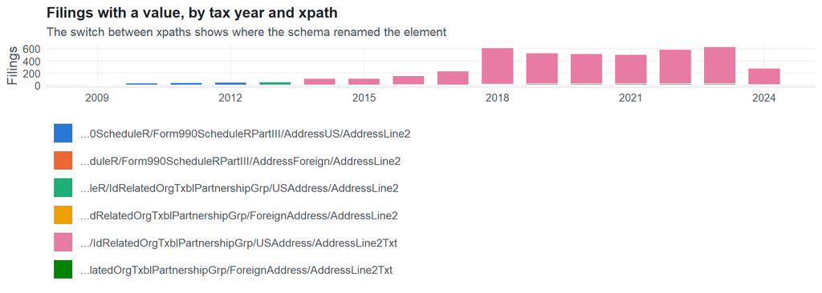

**Table view**

Table view: filings by tax year and series

| Tax year | …0ScheduleR/Form990ScheduleRPartIII/AddressUS/AddressLine2 | …duleR/Form990ScheduleRPartIII/AddressForeign/AddressLine2 | …leR/IdRelatedOrgTxblPartnershipGrp/USAddress/AddressLine2 | …dRelatedOrgTxblPartnershipGrp/ForeignAddress/AddressLine2 | …/IdRelatedOrgTxblPartnershipGrp/USAddress/AddressLine2Txt | …latedOrgTxblPartnershipGrp/ForeignAddress/AddressLine2Txt |
| --- | --- | --- | --- | --- | --- | --- |
| 2009 | 9 | 0 | 0 | 0 | 0 | 0 |
| 2010 | 31 | 0 | 0 | 0 | 0 | 0 |
| 2011 | 42 | 0 | 0 | 0 | 0 | 0 |
| 2012 | 42 | 2 | 0 | 0 | 0 | 0 |
| 2013 | 0 | 0 | 53 | 2 | 0 | 0 |
| 2014 | 0 | 0 | 0 | 0 | 110 | 3 |
| 2015 | 0 | 0 | 0 | 0 | 110 | 4 |
| 2016 | 0 | 0 | 0 | 0 | 148 | 11 |
| 2017 | 0 | 0 | 0 | 0 | 231 | 3 |
| 2018 | 0 | 0 | 0 | 0 | 598 | 12 |
| 2019 | 0 | 0 | 0 | 0 | 511 | 21 |
| 2020 | 0 | 0 | 0 | 0 | 495 | 18 |
| 2021 | 0 | 0 | 0 | 0 | 488 | 18 |
| 2022 | 0 | 0 | 0 | 0 | 569 | 19 |
| 2023 | 0 | 0 | 0 | 0 | 613 | 21 |
| 2024 | 0 | 0 | 0 | 0 | 271 | 5 |

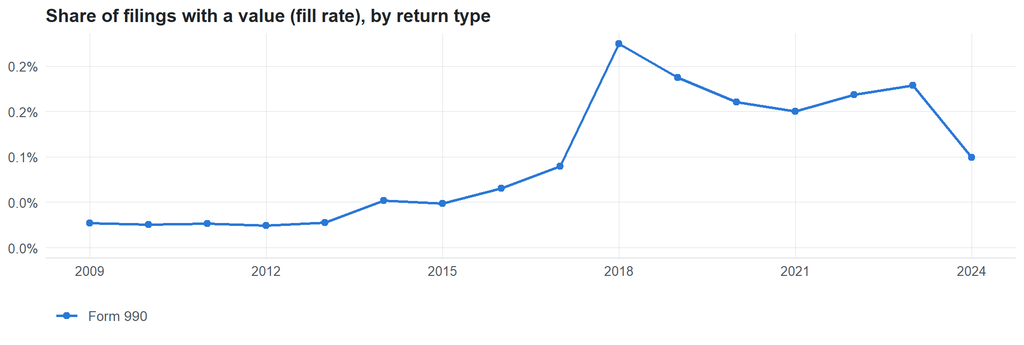

**Table view**

Table view: fill rate

| Tax year | Return type | Filings | All filings | Fill rate |
| --- | --- | --- | --- | --- |
| 2009 | Form 990 | 9 | 33,311 | 0.03% |
| 2010 | Form 990 | 31 | 123,025 | 0.03% |
| 2011 | Form 990 | 42 | 159,504 | 0.03% |
| 2012 | Form 990 | 44 | 179,688 | 0.02% |
| 2013 | Form 990 | 55 | 198,855 | 0.03% |
| 2014 | Form 990 | 113 | 218,619 | 0.05% |
| 2015 | Form 990 | 114 | 233,519 | 0.05% |
| 2016 | Form 990 | 159 | 243,903 | 0.07% |
| 2017 | Form 990 | 234 | 261,612 | 0.09% |
| 2018 | Form 990 | 610 | 271,442 | 0.22% |
| 2019 | Form 990 | 532 | 283,694 | 0.19% |
| 2020 | Form 990 | 513 | 320,342 | 0.16% |
| 2021 | Form 990 | 506 | 336,480 | 0.15% |
| 2022 | Form 990 | 588 | 349,055 | 0.17% |
| 2023 | Form 990 | 634 | 354,768 | 0.18% |
| 2024 | Form 990 | 276 | 277,298 | 0.10% |

## Repeating groups

Table cardinality in the concordance: **many**. 4 of 6 observed xpaths repeat within a filing.

Repeating element each xpath was observed in (from the raw indexed xpath)

| Xpath | Repeating element | Filings (summed over years) |
| --- | --- | --- |
| IRS990ScheduleR/Form990ScheduleRPartIII/AddressUS/AddressLine2 | (none) | 65 |
| IRS990ScheduleR/Form990ScheduleRPartIII/AddressUS/AddressLine2 | IRS990ScheduleR/Form990ScheduleRPartIII | 59 |
| IRS990ScheduleR/Form990ScheduleRPartIII/AddressForeign/AddressLine2 | (none) | 2 |
| IRS990ScheduleR/IdRelatedOrgTxblPartnershipGrp/ForeignAddress/AddressLine2 | (none) | 2 |
| IRS990ScheduleR/IdRelatedOrgTxblPartnershipGrp/USAddress/AddressLine2 | (none) | 28 |
| IRS990ScheduleR/IdRelatedOrgTxblPartnershipGrp/USAddress/AddressLine2 | IRS990ScheduleR/IdRelatedOrgTxblPartnershipGrp | 25 |
| IRS990ScheduleR/IdRelatedOrgTxblPartnershipGrp/ForeignAddress/AddressLine2Txt | (none) | 12 |
| IRS990ScheduleR/IdRelatedOrgTxblPartnershipGrp/ForeignAddress/AddressLine2Txt | IRS990ScheduleR/IdRelatedOrgTxblPartnershipGrp | 123 |
| IRS990ScheduleR/IdRelatedOrgTxblPartnershipGrp/USAddress/AddressLine2Txt | (none) | 433 |
| IRS990ScheduleR/IdRelatedOrgTxblPartnershipGrp/USAddress/AddressLine2Txt | IRS990ScheduleR/IdRelatedOrgTxblPartnershipGrp | 3711 |

## Values

[output not shown]

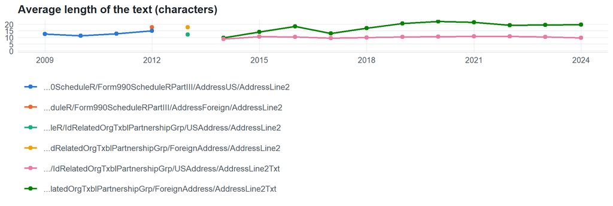

**Table view**

Table view: length and variety by tax year

| Series | Tax year | Filings | Avg length | Max length | Distinct values (approx.) |
| --- | --- | --- | --- | --- | --- |
| …0ScheduleR/Form990ScheduleRPartIII/AddressUS/AddressLine2 | 2009 | 9 | 13 | 28 | 6 |
| …0ScheduleR/Form990ScheduleRPartIII/AddressUS/AddressLine2 | 2010 | 31 | 11 | 28 | 16 |
| …0ScheduleR/Form990ScheduleRPartIII/AddressUS/AddressLine2 | 2011 | 42 | 13 | 32 | 29 |
| …0ScheduleR/Form990ScheduleRPartIII/AddressUS/AddressLine2 | 2012 | 42 | 15 | 27 | 33 |
| …duleR/Form990ScheduleRPartIII/AddressForeign/AddressLine2 | 2012 | 2 | 18 | 18 | 2 |
| …leR/IdRelatedOrgTxblPartnershipGrp/USAddress/AddressLine2 | 2013 | 53 | 12 | 28 | 52 |
| …dRelatedOrgTxblPartnershipGrp/ForeignAddress/AddressLine2 | 2013 | 2 | 18 | 18 | 1 |
| …/IdRelatedOrgTxblPartnershipGrp/USAddress/AddressLine2Txt | 2014 | 110 | 9 | 27 | 65 |
| …/IdRelatedOrgTxblPartnershipGrp/USAddress/AddressLine2Txt | 2015 | 110 | 11 | 29 | 68 |
| …/IdRelatedOrgTxblPartnershipGrp/USAddress/AddressLine2Txt | 2016 | 148 | 10 | 29 | 106 |
| …/IdRelatedOrgTxblPartnershipGrp/USAddress/AddressLine2Txt | 2017 | 231 | 9 | 34 | 65 |
| …/IdRelatedOrgTxblPartnershipGrp/USAddress/AddressLine2Txt | 2018 | 598 | 10 | 34 | 124 |
| …/IdRelatedOrgTxblPartnershipGrp/USAddress/AddressLine2Txt | 2019 | 511 | 10 | 34 | 165 |
| …/IdRelatedOrgTxblPartnershipGrp/USAddress/AddressLine2Txt | 2020 | 495 | 11 | 34 | 203 |
| …/IdRelatedOrgTxblPartnershipGrp/USAddress/AddressLine2Txt | 2021 | 488 | 11 | 34 | 165 |
| …/IdRelatedOrgTxblPartnershipGrp/USAddress/AddressLine2Txt | 2022 | 569 | 11 | 34 | 188 |
| …/IdRelatedOrgTxblPartnershipGrp/USAddress/AddressLine2Txt | 2023 | 613 | 10 | 34 | 167 |
| …/IdRelatedOrgTxblPartnershipGrp/USAddress/AddressLine2Txt | 2024 | 271 | 10 | 34 | 92 |
| …latedOrgTxblPartnershipGrp/ForeignAddress/AddressLine2Txt | 2014 | 3 | 10 | 17 | 2 |
| …latedOrgTxblPartnershipGrp/ForeignAddress/AddressLine2Txt | 2015 | 4 | 14 | 18 | 4 |
| …latedOrgTxblPartnershipGrp/ForeignAddress/AddressLine2Txt | 2016 | 11 | 18 | 22 | 7 |
| …latedOrgTxblPartnershipGrp/ForeignAddress/AddressLine2Txt | 2017 | 3 | 13 | 18 | 2 |
| …latedOrgTxblPartnershipGrp/ForeignAddress/AddressLine2Txt | 2018 | 12 | 17 | 23 | 5 |
| …latedOrgTxblPartnershipGrp/ForeignAddress/AddressLine2Txt | 2019 | 21 | 20 | 31 | 16 |
| …latedOrgTxblPartnershipGrp/ForeignAddress/AddressLine2Txt | 2020 | 18 | 22 | 29 | 10 |
| …latedOrgTxblPartnershipGrp/ForeignAddress/AddressLine2Txt | 2021 | 18 | 21 | 29 | 9 |
| …latedOrgTxblPartnershipGrp/ForeignAddress/AddressLine2Txt | 2022 | 19 | 19 | 24 | 13 |
| …latedOrgTxblPartnershipGrp/ForeignAddress/AddressLine2Txt | 2023 | 21 | 19 | 32 | 13 |
| …latedOrgTxblPartnershipGrp/ForeignAddress/AddressLine2Txt | 2024 | 5 | 20 | 27 | 2 |

Most common values by xpath (all years; long values truncated)

| Series | Value | Filings | Share |
| --- | --- | --- | --- |
| …0ScheduleR/Form990ScheduleRPartIII/AddressUS/AddressLine2 | Suite 1200 | 5 | 4.0% |
| …0ScheduleR/Form990ScheduleRPartIII/AddressUS/AddressLine2 | Bld A Ste 106 | 4 | 3.2% |
| …0ScheduleR/Form990ScheduleRPartIII/AddressUS/AddressLine2 | SUITE 102 | 4 | 3.2% |
| …0ScheduleR/Form990ScheduleRPartIII/AddressUS/AddressLine2 | Suite 201 | 4 | 3.2% |
| …0ScheduleR/Form990ScheduleRPartIII/AddressUS/AddressLine2 | PO BOX 178 | 3 | 2.4% |
| …0ScheduleR/Form990ScheduleRPartIII/AddressUS/AddressLine2 | SUITE 1240 | 3 | 2.4% |
| …0ScheduleR/Form990ScheduleRPartIII/AddressUS/AddressLine2 | SUITE 300 | 3 | 2.4% |
| …0ScheduleR/Form990ScheduleRPartIII/AddressUS/AddressLine2 | SUITE LL 200 | 3 | 2.4% |
| …0ScheduleR/Form990ScheduleRPartIII/AddressUS/AddressLine2 | SUITE LL200 | 3 | 2.4% |
| …0ScheduleR/Form990ScheduleRPartIII/AddressUS/AddressLine2 | SUITE S-15 | 3 | 2.4% |
| …0ScheduleR/Form990ScheduleRPartIII/AddressUS/AddressLine2 | 400 LOCUST STREET | 3 | 2.4% |
| …0ScheduleR/Form990ScheduleRPartIII/AddressUS/AddressLine2 | 1086 FRANKLIN STREET | 2 | 1.6% |
| …0ScheduleR/Form990ScheduleRPartIII/AddressUS/AddressLine2 | 111 GOOSE LANE | 2 | 1.6% |
| …0ScheduleR/Form990ScheduleRPartIII/AddressUS/AddressLine2 | 12TH FLOOR | 2 | 1.6% |
| …0ScheduleR/Form990ScheduleRPartIII/AddressUS/AddressLine2 | 1450 SCALP AVENUE | 2 | 1.6% |
| …0ScheduleR/Form990ScheduleRPartIII/AddressUS/AddressLine2 | 11 BITTERSWEET LANE | 2 | 1.6% |
| …0ScheduleR/Form990ScheduleRPartIII/AddressUS/AddressLine2 | 42 OZICK DRIVE 5 | 2 | 1.6% |
| …0ScheduleR/Form990ScheduleRPartIII/AddressUS/AddressLine2 | 618 SAW MILL RIVER ROAD | 2 | 1.6% |
| …0ScheduleR/Form990ScheduleRPartIII/AddressUS/AddressLine2 | 693 RIVER ROAD | 2 | 1.6% |
| …0ScheduleR/Form990ScheduleRPartIII/AddressUS/AddressLine2 | 13261 MID ATLANTIC BLVD | 2 | 1.6% |
| …0ScheduleR/Form990ScheduleRPartIII/AddressUS/AddressLine2 | 1330 BEAULAH ROAD | 2 | 1.6% |
| …0ScheduleR/Form990ScheduleRPartIII/AddressUS/AddressLine2 | 220 WEST GRANT AVENUE | 2 | 1.6% |
| …0ScheduleR/Form990ScheduleRPartIII/AddressUS/AddressLine2 | 30 FIFTY FIRST STREET | 2 | 1.6% |
| …0ScheduleR/Form990ScheduleRPartIII/AddressUS/AddressLine2 | 900 ART ROONEY AVE | 2 | 1.6% |
| …0ScheduleR/Form990ScheduleRPartIII/AddressUS/AddressLine2 | 60 TEMPLE STREET | 1 | 0.8% |
| …0ScheduleR/Form990ScheduleRPartIII/AddressUS/AddressLine2 | PHYSICIAN PLAZA WEST STE 102 | 1 | 0.8% |
| …0ScheduleR/Form990ScheduleRPartIII/AddressUS/AddressLine2 | PO BOX 728 | 1 | 0.8% |
| …0ScheduleR/Form990ScheduleRPartIII/AddressUS/AddressLine2 | 1520 COOPER HILL ROAD | 1 | 0.8% |
| …0ScheduleR/Form990ScheduleRPartIII/AddressUS/AddressLine2 | 1644 MILEGROUND | 1 | 0.8% |
| …0ScheduleR/Form990ScheduleRPartIII/AddressUS/AddressLine2 | 2451 GRANT AVENUE | 1 | 0.8% |

First rows shown.

## Examples

| Tax year | Return | Xpath | Organization | Value | Source |
| --- | --- | --- | --- | --- | --- |
| 2024 | 990 | IRS990ScheduleR/IdRelatedOrgTxblPartnershipGrp/ForeignAddress/AddressLine2Txt | PLANET WATER FOUNDATION | WATTHANA | [XML](https://gt990datalake-rawdata.s3.amazonaws.com/EfileData/XmlFiles/202521279349301437_public.xml) |
| 2024 | 990 | IRS990ScheduleR/IdRelatedOrgTxblPartnershipGrp/USAddress/AddressLine2Txt | Baptist Health Hospitals | Suite 200 | [XML](https://gt990datalake-rawdata.s3.amazonaws.com/EfileData/XmlFiles/202543179349309514_public.xml) |
| 2023 | 990 | IRS990ScheduleR/IdRelatedOrgTxblPartnershipGrp/ForeignAddress/AddressLine2Txt | Harvard Real Estate - Allston Inc | PO BOX 309 UGLAND HOUSE | [XML](https://gt990datalake-rawdata.s3.amazonaws.com/EfileData/XmlFiles/202541359349307959_public.xml) |
| 2023 | 990 | IRS990ScheduleR/IdRelatedOrgTxblPartnershipGrp/USAddress/AddressLine2Txt | ASCENSION PROVIDENCE ROCHESTER FOUNDATION | PO BOX 45998 | [XML](https://gt990datalake-rawdata.s3.amazonaws.com/EfileData/XmlFiles/202511359349304421_public.xml) |
| 2022 | 990 | IRS990ScheduleR/IdRelatedOrgTxblPartnershipGrp/ForeignAddress/AddressLine2Txt | CHANCELLOR MASTERS & SCHOLARS OF THE UNIVERSITY OF OXFORD | Wellington Square | [XML](https://gt990datalake-rawdata.s3.amazonaws.com/EfileData/XmlFiles/202411239349300806_public.xml) |
| 2022 | 990 | IRS990ScheduleR/IdRelatedOrgTxblPartnershipGrp/USAddress/AddressLine2Txt | Humility House | Suite 210 | [XML](https://gt990datalake-rawdata.s3.amazonaws.com/EfileData/XmlFiles/202332719349302108_public.xml) |
| 2021 | 990 | IRS990ScheduleR/IdRelatedOrgTxblPartnershipGrp/ForeignAddress/AddressLine2Txt | President and Fellows of Harvard College | PO BOX 309 UGLAND HOUSE | [XML](https://gt990datalake-rawdata.s3.amazonaws.com/EfileData/XmlFiles/202311319349301331_public.xml) |
| 2021 | 990 | IRS990ScheduleR/IdRelatedOrgTxblPartnershipGrp/USAddress/AddressLine2Txt | Methodist-CDI | 400 | [XML](https://gt990datalake-rawdata.s3.amazonaws.com/EfileData/XmlFiles/202233199349316433_public.xml) |
| 2020 | 990 | IRS990ScheduleR/IdRelatedOrgTxblPartnershipGrp/ForeignAddress/AddressLine2Txt | HARVARD PRIVATE CAPITAL REALTY INC | PO Box 309 Ugland House | [XML](https://gt990datalake-rawdata.s3.amazonaws.com/EfileData/XmlFiles/202231329349305628_public.xml) |
| 2020 | 990 | IRS990ScheduleR/IdRelatedOrgTxblPartnershipGrp/USAddress/AddressLine2Txt | Bon Secours Mercy Health Inc | SUITE 200 | [XML](https://gt990datalake-rawdata.s3.amazonaws.com/EfileData/XmlFiles/202143169349303074_public.xml) |
| 2019 | 990 | IRS990ScheduleR/IdRelatedOrgTxblPartnershipGrp/ForeignAddress/AddressLine2Txt | Harvard Management Private Equity Corp | PO Box 309 Ugland House | [XML](https://gt990datalake-rawdata.s3.amazonaws.com/EfileData/XmlFiles/202121339349303382_public.xml) |
| 2019 | 990 | IRS990ScheduleR/IdRelatedOrgTxblPartnershipGrp/USAddress/AddressLine2Txt | ASCENSION STANDISH HOSPITAL | SUITE 200 | [XML](https://gt990datalake-rawdata.s3.amazonaws.com/EfileData/XmlFiles/202111339349302336_public.xml) |

## Reviewer checklist

- The definition matches the form line and instructions for every xpath’s schema years.
- Every xpath pooled here measures the same thing on the 990 and 990-EZ (close enough for analysis).
- The coverage chart has no unexplained gaps or jumps between tax years.
- Each open flag is fixed, or accepted with a note in validation_log.csv.
- Values answer the question on the form line (not another line’s explanation).
- Boilerplate such as ‘See Schedule O’ or ‘N/A’ is expected here, or should be treated as missing.
- Text that is really a number or a code is flagged for a different data type.

Record the review as a row in `inst/extdata/src/validation_log.csv` (variable_name, reviewer, date, status, note). Evidence built 2026-09-23 17:09:04 MST from the ef2 DuckDB builds (tax years 2009–2024).